# Cvicenie 11.15 - Bayesianska Regresia pre Perth Weather

Baesiánska analýza - Týden 11

Dana Kozáková

2025-11-26

# Zadanie

**Exercise 11.15**: Pouzite data `weather_perth` z balicka `bayesrules` na vytvorenie “uspesneho” modelu poobednajsich teplot (`temp3pm`) v Perth, Australia. Mozete si vybrat, ktore prediktory pouzijete a ci zahrnute interakcne cleny. Nezabudnite vyhodnotit vas model a vysvetlit proces modelovania.

# Teoreticky Uvod

## Multivariabilna Bayesianska Normalna Regresia

Pre kvantitativnu odpoved $Y$ a mnozinu $p$ prediktorov $(X_1, X_2, \ldots, X_p)$ ma multivariabilny Bayesianov normalny regresny model nasledujucu strukturu:

$$\begin{aligned}
\text{Data:} \quad Y_i | \beta_0, \beta_1, \ldots, \beta_p, \sigma
&\stackrel{ind}{\sim} N(\mu_i, \sigma^2) \\
\text{kde} \quad \mu_i &= \beta_0 + \beta_1 X_{i1} + \beta_2 X_{i2}
+ \cdots + \beta_p X_{ip}
\end{aligned}$$

## Priory pre parametre

$$\begin{aligned}
\beta_{0c} &\sim N(m_0, s_0^2) \\
\beta_j &\sim N(0, s_j^2) \quad \text{pre } j = 1, \ldots, p \\
\sigma &\sim \text{Exp}(l)
\end{aligned}$$

## Interpretacia koeficientov

- **$\beta_0$** (Intercept): Typicka hodnota $Y$ ked vsetky prediktory su 0
- **$\beta_j$ pre kvantitativny prediktor**: Typicka zmena v $Y$ pri jednotkovom naraste $X_j$, pri kontrole ostatnych prediktorov
- **$\beta_j$ pre kategoricky prediktor**: Typicky rozdiel v $Y$ medzi danou kategoriu a referencnou kategoriu
- **$\sigma$**: Standardna odchylka rezidui

## Bias-Variance Trade-off

Pri budovani modelu hladame rovnovahu:

- **Prilis jednoduchy model** (malo prediktorov): Vysoky bias, nizka variancia
- **Prilis zlozity model** (vela prediktorov): Nizky bias, vysoka variancia (overfitting)

# Nacitanie Balickov a Dat

```r
# Nacitanie potrebnych balickov
library(bayesrules)
library(rstanarm)
library(bayesplot)
library(tidyverse)
library(broom.mixed)
library(tidybayes)
library(patchwork)

# Nacitanie dat
data(weather_perth)
```

# Prieskumna Analyza Dat (EDA)

## Struktura dat

```r
# load data
data(weather_perth)

# Prehlad dat
glimpse(weather_perth)
```

```
## Rows: 1,000
## Columns: 21
## $ mintemp       <dbl> 19.6, 18.4, 11.7, 13.0, 17.8, 9.7, 17.9, 9.7, 11.2, 12.9…
## $ maxtemp       <dbl> 32.3, 34.7, 19.8, 24.9, 28.5, 21.6, 31.0, 27.4, 17.9, 19…
## $ rainfall      <dbl> 0.0, 0.0, 0.6, 0.0, 0.0, 2.2, 0.0, 0.0, 9.0, 13.6, 0.0, …
## $ windgustdir   <ord> E, ENE, WNW, SW, SSW, SW, SSW, SW, WNW, W, SSE, ENE, SSW…
## $ windgustspeed <dbl> 31, 37, 48, 44, 39, 24, 30, 33, 52, 31, 30, 20, 26, 35, …
## $ winddir9am    <ord> E, E, WNW, S, S, NE, E, ENE, W, NNE, ESE, NE, SE, NNE, S…
## $ winddir3pm    <ord> SW, SE, WNW, SSW, SW, W, WSW, SW, W, W, WSW, SE, S, S, S…
## $ windspeed9am  <dbl> 7, 17, 15, 9, 15, 7, 7, 9, 19, 9, 11, 4, 9, 2, 7, 22, 7,…
## $ windspeed3pm  <dbl> 15, 15, 15, 24, 20, 11, 13, 17, 20, 15, 17, 4, 9, 15, 20…
## $ humidity9am   <int> 55, 43, 62, 53, 65, 84, 48, 51, 47, 90, 53, 87, 83, 96, …
## $ humidity3pm   <int> 44, 16, 85, 46, 51, 59, 43, 34, 47, 57, 42, 46, 55, 56, …
## $ pressure9am   <dbl> 1009.8, 1010.9, 1013.8, 1019.3, 1012.8, 1024.7, 1007.6, …
## $ pressure3pm   <dbl> 1007.1, 1006.5, 1012.1, 1015.5, 1010.8, 1022.4, 1005.6, …
## $ temp9am       <dbl> 25.3, 24.6, 17.4, 19.7, 24.2, 15.4, 25.3, 21.0, 16.7, 15…
## $ temp3pm       <dbl> 30.0, 33.7, 16.5, 22.8, 26.8, 20.3, 28.1, 25.8, 17.5, 18…
## $ raintoday     <fct> No, No, No, No, No, Yes, No, No, Yes, Yes, No, No, Yes, …
## $ risk_mm       <dbl> 0.0, 0.0, 3.4, 0.0, 0.0, 0.0, 0.0, 0.0, 5.0, 4.8, 0.0, 0…
## $ raintomorrow  <fct> No, No, Yes, No, No, No, No, No, Yes, Yes, No, No, No, N…
## $ year          <dbl> 2014, 2011, 2013, 2014, 2011, 2014, 2013, 2015, 2019, 20…
## $ month         <dbl> 2, 1, 9, 12, 12, 9, 12, 10, 10, 8, 11, 7, 8, 6, 8, 8, 2,…
## $ day_of_year   <dbl> 45, 11, 261, 347, 357, 254, 364, 293, 304, 231, 313, 208…
```

```r
# Zakladne statistiky
summary(weather_perth)
```

```
##     mintemp        maxtemp         rainfall       windgustdir  windgustspeed
##  Min.   : 0.3   Min.   :13.90   Min.   : 0.000   SW     :241   Min.   :13.00
##  1st Qu.: 9.7   1st Qu.:20.70   1st Qu.: 0.000   SSW    :150   1st Qu.:30.00
##  Median :13.7   Median :24.60   Median : 0.000   NE     : 96   Median :35.00
##  Mean   :13.3   Mean   :25.58   Mean   : 1.495   WSW    : 88   Mean   :35.07
##  3rd Qu.:17.0   3rd Qu.:30.12   3rd Qu.: 0.200   ENE    : 50   3rd Qu.:41.00
##  Max.   :29.7   Max.   :42.70   Max.   :51.200   ESE    : 44   Max.   :76.00
##                                                  (Other):331
##    winddir9am    winddir3pm   windspeed9am    windspeed3pm    humidity9am
##  E      :151   SW     :242   Min.   : 2.00   Min.   : 2.00   Min.   :13.00
##  NE     :121   WSW    :135   1st Qu.: 7.00   1st Qu.:11.00   1st Qu.:49.00
##  ENE    :112   SSW    :113   Median :11.00   Median :15.00   Median :59.00
##  SSE    : 86   W      : 99   Mean   :11.22   Mean   :14.59   Mean   :60.87
##  ESE    : 79   E      : 51   3rd Qu.:15.00   3rd Qu.:19.00   3rd Qu.:73.00
##  NNE    : 73   SE     : 49   Max.   :28.00   Max.   :28.00   Max.   :99.00
##  (Other):378   (Other):311
##   humidity3pm    pressure9am    pressure3pm      temp9am         temp3pm
##  Min.   : 8.0   Min.   :1001   Min.   :1000   Min.   : 7.30   Min.   :11.2
##  1st Qu.:35.0   1st Qu.:1013   1st Qu.:1011   1st Qu.:15.20   1st Qu.:19.5
##  Median :46.0   Median :1017   Median :1015   Median :19.10   Median :23.1
##  Mean   :45.8   Mean   :1018   Mean   :1015   Mean   :19.09   Mean   :24.0
##  3rd Qu.:56.0   3rd Qu.:1022   3rd Qu.:1019   3rd Qu.:22.80   3rd Qu.:28.2
##  Max.   :99.0   Max.   :1038   Max.   :1034   Max.   :39.00   Max.   :41.8
##
##  raintoday    risk_mm       raintomorrow      year          month
##  No :816   Min.   : 0.000   No :814      Min.   :2008   Min.   : 1.000
##  Yes:184   1st Qu.: 0.000   Yes:186      1st Qu.:2011   1st Qu.: 3.000
##            Median : 0.000                Median :2013   Median : 7.000
##            Mean   : 1.634                Mean   :2014   Mean   : 6.601
##            3rd Qu.: 0.200                3rd Qu.:2017   3rd Qu.:10.000
##            Max.   :47.200                Max.   :2020   Max.   :12.000
##
##   day_of_year
##  Min.   :  1.0
##  1st Qu.: 86.0
##  Median :194.5
##  Mean   :185.6
##  3rd Qu.:283.0
##  Max.   :365.0
##
```

## Dostupne premenne

```r
# Zoznam premennych
names(weather_perth)
```

```
##  [1] "mintemp"       "maxtemp"       "rainfall"      "windgustdir"
##  [5] "windgustspeed" "winddir9am"    "winddir3pm"    "windspeed9am"
##  [9] "windspeed3pm"  "humidity9am"   "humidity3pm"   "pressure9am"
## [13] "pressure3pm"   "temp9am"       "temp3pm"       "raintoday"
## [17] "risk_mm"       "raintomorrow"  "year"          "month"
## [21] "day_of_year"
```

## Vizualizacia odpovede

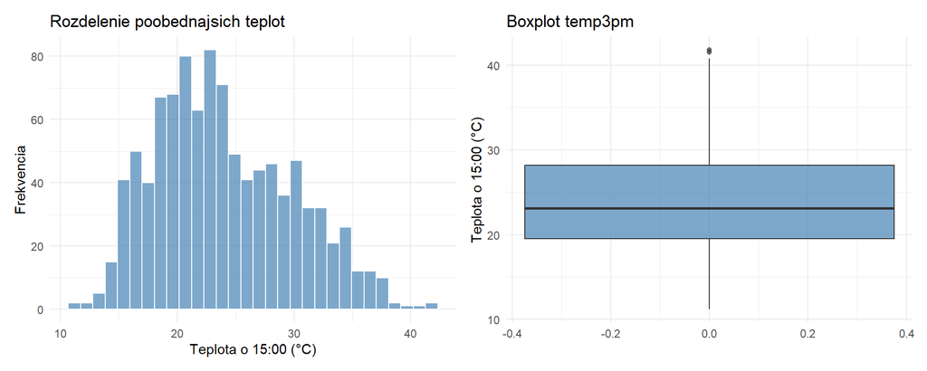

```r
# Rozdelenie temp3pm
p1 <- ggplot(weather_perth, aes(x = temp3pm)) +
  geom_histogram(bins = 30, fill = "steelblue", color = "white", alpha = 0.7) +
  labs(title = "Rozdelenie poobednajsich teplot",
       x = "Teplota o 15:00 (°C)", y = "Frekvencia") +
  theme_minimal()

p2 <- ggplot(weather_perth, aes(y = temp3pm)) +
  geom_boxplot(fill = "steelblue", alpha = 0.7) +
  labs(title = "Boxplot temp3pm",
       y = "Teplota o 15:00 (°C)") +
  theme_minimal()

p1 + p2
```

## Vztahy medzi premennymi

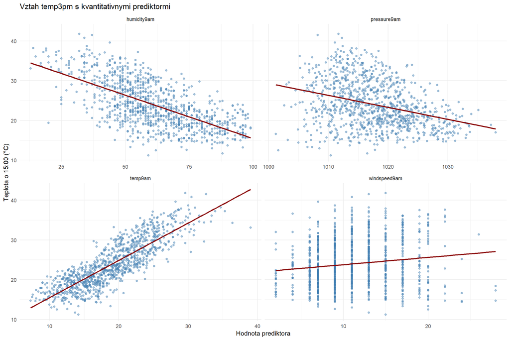

```r
# Vztahy s kvantitativnymi prediktormi
weather_perth %>%
  select(temp3pm, temp9am, humidity9am, pressure9am, windspeed9am) %>%
  pivot_longer(cols = -temp3pm, names_to = "prediktor", values_to = "hodnota") %>%
  ggplot(aes(x = hodnota, y = temp3pm)) +
  geom_point(alpha = 0.5, color = "steelblue") +
  geom_smooth(method = "lm", se = FALSE, color = "darkred") +
  facet_wrap(~prediktor, scales = "free_x") +
  labs(title = "Vztah temp3pm s kvantitativnymi prediktormi",
       x = "Hodnota prediktora", y = "Teplota o 15:00 (°C)") +
  theme_minimal()
```

## Korelacna matica

```r
# Korelacna matica pre kvantitativne premenne
weather_perth %>%
  select(temp3pm, temp9am, humidity9am, pressure9am, windspeed9am) %>%
  cor(use = "complete.obs") %>%
  round(3)
```

```
##              temp3pm temp9am humidity9am pressure9am windspeed9am
## temp3pm        1.000   0.845      -0.648      -0.332        0.145
## temp9am        0.845   1.000      -0.625      -0.601        0.199
## humidity9am   -0.648  -0.625       1.000       0.164       -0.382
## pressure9am   -0.332  -0.601       0.164       1.000       -0.243
## windspeed9am   0.145   0.199      -0.382      -0.243        1.000
```

# Strategia Modelovania

Na zaklade EDA volim nasledujuci pristup:

## Prior Specifikacia

Vychadzam z nasledujuceho predporozumenia:

- Typicka poobednasjia teplota v Perth je niekde medzi 15 a 35°C (stredna hodnota ~25°C)
- Pouzijeme weakly informative priory pre ostatne parametre

$$\begin{aligned}
\beta_{0c} &\sim N(25, 5^2) \\
\beta_j &\sim N(0, 2.5^2) \quad \text{(autoscaled)} \\
\sigma &\sim \text{Exp}(1) \quad \text{(autoscaled)}
\end{aligned}$$

# Model 1: Jednoduchy Model (temp9am)

## Specifikacia modelu

$$\begin{aligned}
Y_i | \beta_0, \beta_1, \sigma &\stackrel{ind}{\sim} N(\mu_i,
\sigma^2) \\
\mu_i &= \beta_0 + \beta_1 \cdot \text{temp9am}_i
\end{aligned}$$

## Simulacia posterioru

```r
set.seed(84735)
model_1 <- stan_glm(
  temp3pm ~ temp9am,
  data = weather_perth,
  family = gaussian,
  prior_intercept = normal(25, 5),
  prior = normal(0, 2.5, autoscale = TRUE),
  prior_aux = exponential(1, autoscale = TRUE),
  chains = 4, iter = 5000*2, seed = 84735,
  refresh = 0
)

prior_summary(model_1)
```

```
## Priors for model 'model_1'
## ------
## Intercept (after predictors centered)
##  ~ normal(location = 25, scale = 5)
##
## Coefficients
##   Specified prior:
##     ~ normal(location = 0, scale = 2.5)
##   Adjusted prior:
##     ~ normal(location = 0, scale = 2.8)
##
## Auxiliary (sigma)
##   Specified prior:
##     ~ exponential(rate = 1)
##   Adjusted prior:
##     ~ exponential(rate = 0.17)
## ------
## See help('prior_summary.stanreg') for more details
```

## MCMC Diagnostika

### Trace plots

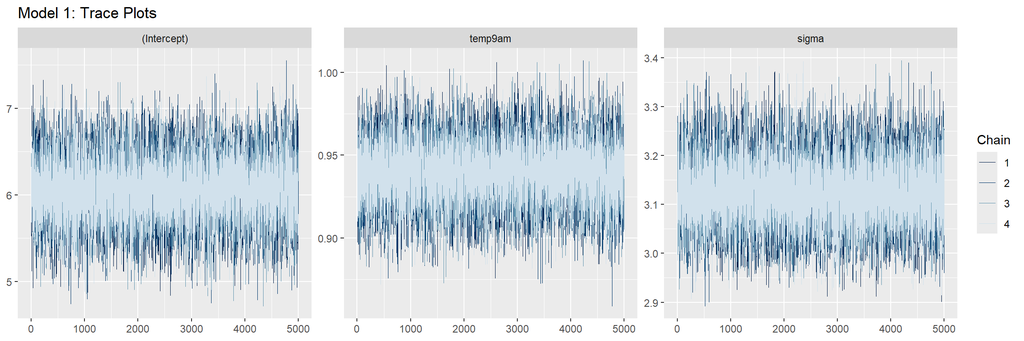

```r
mcmc_trace(model_1, size = 0.1) +
  labs(title = "Model 1: Trace Plots")
```

### Density overlay

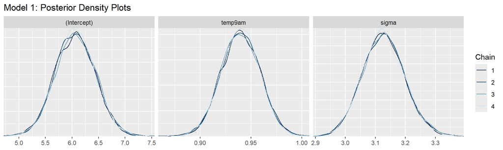

```r
mcmc_dens_overlay(model_1) +
  labs(title = "Model 1: Posterior Density Plots")
```

### Autokorelace

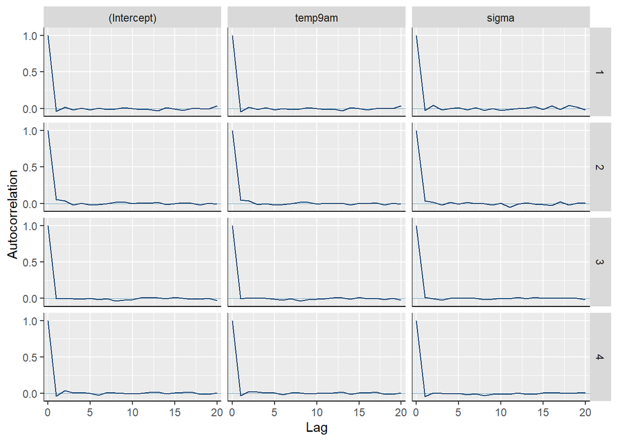

```r
mcmc_acf(model_1)
```

### R-hat

```r
rhat(model_1)
```

```
## (Intercept)     temp9am       sigma
##   1.0000184   0.9999971   1.0000390
```

### ESS - Effective sample size ratio

```r
neff_ratio(model_1)
```

```
## (Intercept)     temp9am       sigma
##     0.98315     0.96920     1.00065
```

## Posterior Summary

```r
# Posterior summary
tidy(model_1, effects = c("fixed", "aux"),
     conf.int = TRUE, conf.level = 0.80) %>%
  select(-std.error)
```

```
## # A tibble: 4 × 4
##   term        estimate conf.low conf.high
##   <chr>          <dbl>    <dbl>     <dbl>
## 1 (Intercept)    6.06     5.59      6.54
## 2 temp9am        0.940    0.916     0.964
## 3 sigma          3.13     3.04      3.22
## 4 mean_PPD      24.0     23.8      24.2
```

## Posterior credible intervals

```r
posterior_interval(model_1, prob = 0.80)
```

```
##                   10%       90%
## (Intercept) 5.5861102 6.5387730
## temp9am     0.9155941 0.9635631
## sigma       3.0379072 3.2168384
```

## Posterior predictive check

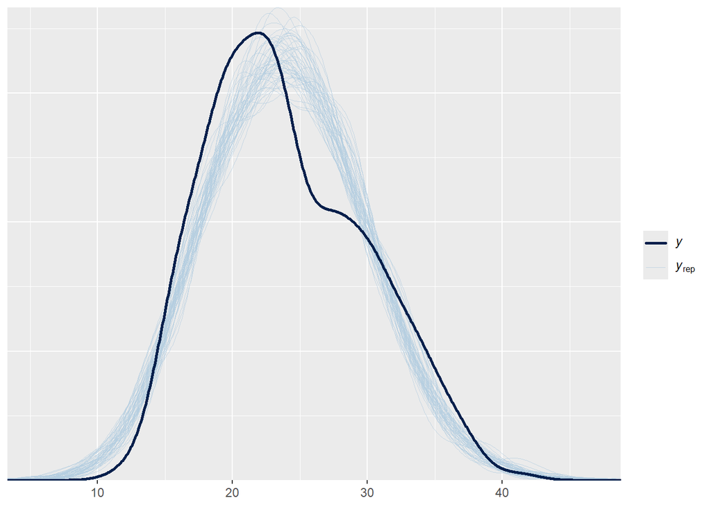

```r
pp_check(model_1)
```

## Interpretacia Model 1

- **Intercept ($\beta_0$)**: Ked je ranna teplota 0°C, ocakavana poobednasjia teplota
- **temp9am ($\beta_1$)**: Za kazdy 1°C narast rannej teploty sa poobednasjia teplota zvysi priblizne o tento koeficient

# Model 2: Dva Prediktory (temp9am + humidity9am)

## Specifikacia modelu

$$\begin{aligned}
Y_i | \beta_0, \beta_1, \beta_2, \sigma &\stackrel{ind}{\sim}
N(\mu_i, \sigma^2) \\
\mu_i &= \beta_0 + \beta_1 \cdot \text{temp9am}_i + \beta_2 \cdot
\text{humidity9am}_i
\end{aligned}$$

## Simulacia posterioru

```r
model_2 <- stan_glm(
  temp3pm ~ temp9am + humidity9am,
  data = weather_perth,
  family = gaussian,
  prior_intercept = normal(25, 5),
  prior = normal(0, 2.5, autoscale = TRUE),
  prior_aux = exponential(1, autoscale = TRUE),
  chains = 4, iter = 5000*2, seed = 84735,
  refresh = 0
)
```

## MCMC Diagnostika

```r
# R-hat
cat("Model 2 R-hat hodnoty:\n")
```

```
## Model 2 R-hat hodnoty:
```

```r
rhat(model_2)
```

```
## (Intercept)     temp9am humidity9am       sigma
##   1.0003317   1.0002576   1.0003122   0.9999479
```

```r
cat("\nModel 2 ESS Ratios:\n")
```

```
##
## Model 2 ESS Ratios:
```

```r
neff_ratio(model_2)
```

```
## (Intercept)     temp9am humidity9am       sigma
##     0.68650     0.75045     0.75655     0.95395
```

## Posterior Summary

```r
tidy(model_2, effects = c("fixed", "aux"),
     conf.int = TRUE, conf.level = 0.80) %>%
  select(-std.error)
```

```
## # A tibble: 5 × 4
##   term        estimate conf.low conf.high
##   <chr>          <dbl>    <dbl>     <dbl>
## 1 (Intercept)  12.8     11.8      13.8
## 2 temp9am       0.801    0.772     0.832
## 3 humidity9am  -0.0668  -0.0756   -0.0579
## 4 sigma         2.99     2.91      3.08
## 5 mean_PPD     24.0     23.8      24.2
```

## Interpretacia Model 2

Pri kontrole ostatnych prediktorov:

- **temp9am**: Pozitivny vztah s poobednajsiou teplotou
- **humidity9am**: Negativny vztah (vyssia vlhkost = nizsia teplota)

# Model 3: Plny Model

## Specifikacia modelu

$$\begin{aligned}
\mu_i &= \beta_0 + \beta_1 \cdot \text{temp9am}_i + \beta_2 \cdot
\text{humidity9am}_i + \beta_3 \cdot \text{pressure9am}_i + \beta_4
\cdot \text{windspeed9am}_i
\end{aligned}$$

## Simulacia posterioru

```r
set.seed(84735)
model_3 <- stan_glm(
  temp3pm ~ temp9am + humidity9am + pressure9am + windspeed9am,
  data = weather_perth,
  family = gaussian,
  prior_intercept = normal(25, 5),
  prior = normal(0, 2.5, autoscale = TRUE),
  prior_aux = exponential(1, autoscale = TRUE),
  chains = 4, iter = 5000*2, seed = 84735,
  refresh = 0
)
```

## MCMC Diagnostika

```r
cat("Model 3 R-hat hodnoty:\n")
```

```
## Model 3 R-hat hodnoty:
```

```r
rhat(model_3)
```

```
##  (Intercept)      temp9am  humidity9am  pressure9am windspeed9am        sigma
##    0.9998866    0.9999760    1.0000105    0.9998800    1.0000836    0.9999203
```

```r
cat("\nModel 3 ESS Ratios:\n")
```

```
##
## Model 3 ESS Ratios:
```

```r
neff_ratio(model_3)
```

```
##  (Intercept)      temp9am  humidity9am  pressure9am windspeed9am        sigma
##      0.61005      0.55225      0.58935      0.63095      0.78245      0.80470
```

## Posterior Summary

```r
tidy(model_3, effects = c("fixed", "aux"),
     conf.int = TRUE, conf.level = 0.80) %>%
  select(-std.error)
```

```
## # A tibble: 7 × 4
##   term          estimate  conf.low  conf.high
##   <chr>            <dbl>     <dbl>      <dbl>
## 1 (Intercept)  -201.     -226.     -174.
## 2 temp9am         1.01      0.967     1.04
## 3 humidity9am    -0.0445   -0.0544   -0.0346
## 4 pressure9am     0.205     0.180     0.229
## 5 windspeed9am   -0.0374   -0.0659   -0.00908
## 6 sigma           2.81      2.73      2.89
## 7 mean_PPD       24.0      23.8      24.2
```

## 95% Credible Intervals

```r
posterior_interval(model_3, prob = 0.95)
```

```
##                       2.5%         97.5%
## (Intercept)  -240.70233093 -1.602206e+02
## temp9am         0.94719283  1.063419e+00
## humidity9am    -0.05974106 -2.950250e-02
## pressure9am     0.16649897  2.431679e-01
## windspeed9am   -0.08120203  5.800981e-03
## sigma           2.68835056  2.935490e+00
```

## Interpretacia Model 3

# Posterior Predictive Checks

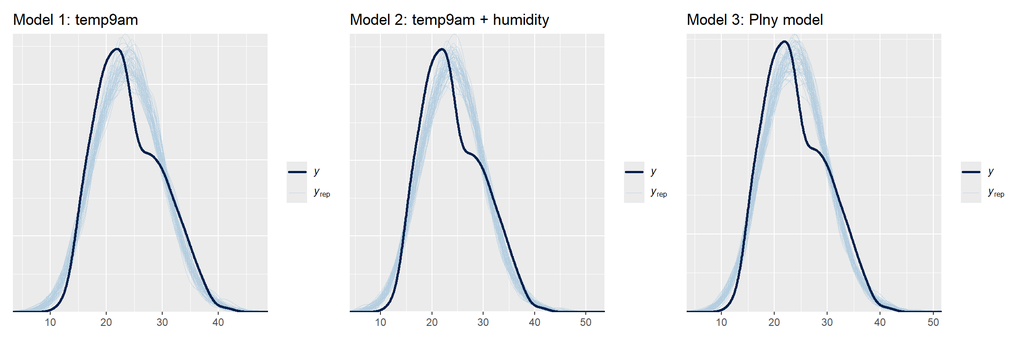

```r
# PP checks pre vsetky modely
p1 <- pp_check(model_1) + labs(title = "Model 1: temp9am")
p2 <- pp_check(model_2) + labs(title = "Model 2: temp9am + humidity")
p3 <- pp_check(model_3) + labs(title = "Model 3: Plny model")

p1 + p2 + p3
```

# Porovnanie Modelov

## Cross-Validation (10-fold)

```r
set.seed(84735)

# Odstranenie NA hodnot pre cross-validaciu
weather_complete <- weather_perth %>%
  select(temp3pm, temp9am, humidity9am, pressure9am, windspeed9am) %>%
  na.omit()

# Cross-validation pre kazdy model
cv_1 <- prediction_summary_cv(model = model_1, data = weather_complete, k = 10)
cv_2 <- prediction_summary_cv(model = model_2, data = weather_complete, k = 10)
cv_3 <- prediction_summary_cv(model = model_3, data = weather_complete, k = 10)
```

```r
# Porovnanie vysledkov
cv_comparison <- data.frame(
  Model = c("Model 1 (temp9am)",
            "Model 2 (temp9am + humidity)",
            "Model 3 (plny)"),
  MAE = c(cv_1$cv$mae, cv_2$cv$mae, cv_3$cv$mae),
  MAE_scaled = c(cv_1$cv$mae_scaled, cv_2$cv$mae_scaled, cv_3$cv$mae_scaled),
  Within_50 = c(cv_1$cv$within_50, cv_2$cv$within_50, cv_3$cv$within_50),
  Within_95 = c(cv_1$cv$within_95, cv_2$cv$within_95, cv_3$cv$within_95)
)

knitr::kable(cv_comparison, digits = 3,
             caption = "Porovnanie Cross-Validated Prediction Metrics")
```

Porovnanie Cross-Validated Prediction Metrics

| Model | MAE | MAE_scaled | Within_50 | Within_95 |
| --- | --- | --- | --- | --- |
| Model 1 (temp9am) | 2.254 | 0.720 | 0.474 | 0.957 |
| Model 2 (temp9am + humidity) | 2.086 | 0.696 | 0.495 | 0.950 |
| Model 3 (plny) | 1.871 | 0.663 | 0.493 | 0.952 |

## ELPD Porovnanie

```r
set.seed(84735)
loo_1 <- loo(model_1)
loo_2 <- loo(model_2)
loo_3 <- loo(model_3)

# ELPD hodnoty
cat("ELPD hodnoty:\n")
```

```
## ELPD hodnoty:
```

```r
cat("Model 1:", loo_1$estimates[1], "\n")
```

```
## Model 1: -2559.943
```

```r
cat("Model 2:", loo_2$estimates[1], "\n")
```

```
## Model 2: -2517.711
```

```r
cat("Model 3:", loo_3$estimates[1], "\n")
```

```
## Model 3: -2454.071
```

```r
# Formalne porovnanie
loo_compare(loo_1, loo_2, loo_3)
```

```
##         elpd_diff se_diff
## model_3    0.0       0.0
## model_2  -63.6      11.0
## model_1 -105.9      12.5
```

## Interpretacia ELPD porovnania

ELPD (Expected Log Predictive Density) porovnanie:

- Modely su zoradene od najlepsieho (najvyssie ELPD) po najhorsie
- Rozdiel `elpd_diff` ukazuje, o kolko je model horsi ako najlepsi
- Ak je `|elpd_diff| < 2 * se_diff`, rozdiel nie je signifikantny

# Zaver a Vyber Modelu

## Suhrn vysledkov

```r
# Finalny suhrn
cat("=== SUHRN POROVNANIA MODELOV ===\n\n")
```

```
## === SUHRN POROVNANIA MODELOV ===
```

```r
cat("Cross-validated MAE:\n")
```

```
## Cross-validated MAE:
```

```r
cat("Model 1:", round(cv_1$cv$mae, 3), "°C\n")
```

```
## Model 1: 2.254 °C
```

```r
cat("Model 2:", round(cv_2$cv$mae, 3), "°C\n")
```

```
## Model 2: 2.086 °C
```

```r
cat("Model 3:", round(cv_3$cv$mae, 3), "°C\n\n")
```

```
## Model 3: 1.871 °C
```

```r
cat("ELPD hodnoty:\n")
```

```
## ELPD hodnoty:
```

```r
cat("Model 1:", round(loo_1$estimates[1], 1), "\n")
```

```
## Model 1: -2559.9
```

```r
cat("Model 2:", round(loo_2$estimates[1], 1), "\n")
```

```
## Model 2: -2517.7
```

```r
cat("Model 3:", round(loo_3$estimates[1], 1), "\n")
```

```
## Model 3: -2454.1
```

## Finalny Model - Posterior Summary

```r
# Detailny suhrn vybraneho modelu
cat("=== FINALNY MODEL: temp3pm ~ temp9am + humidity9am ===\n\n")
```

```
## === FINALNY MODEL: temp3pm ~ temp9am + humidity9am ===
```

```r
tidy(model_2, effects = c("fixed", "aux"),
     conf.int = TRUE, conf.level = 0.95) %>%
  select(-std.error) %>%
  knitr::kable(digits = 3, caption = "Posterior Summary - 95% CI")
```

Posterior Summary - 95% CI

| term | estimate | conf.low | conf.high |
| --- | --- | --- | --- |
| (Intercept) | 12.754 | 11.233 | 14.275 |
| temp9am | 0.801 | 0.757 | 0.847 |
| humidity9am | -0.067 | -0.080 | -0.053 |
| sigma | 2.995 | 2.867 | 3.131 |
| mean_PPD | 24.001 | 23.736 | 24.266 |

## Posterior Median Model Equation

Na zaklade posteriornych median hodnot:

$$\widehat{\text{temp3pm}} = \hat{\beta}_0 + \hat{\beta}_1 \cdot
\text{temp9am} + \hat{\beta}_2 \cdot \text{humidity9am}$$

```r
coefs <- tidy(model_2)$estimate[1:3]
cat(sprintf("temp3pm = %.2f + %.3f * temp9am + %.4f * humidity9am\n",
            coefs[1], coefs[2], coefs[3]))
```

```
## temp3pm = 12.75 + 0.801 * temp9am + -0.0668 * humidity9am
```

## Posterior Predikcna Vizualizacia

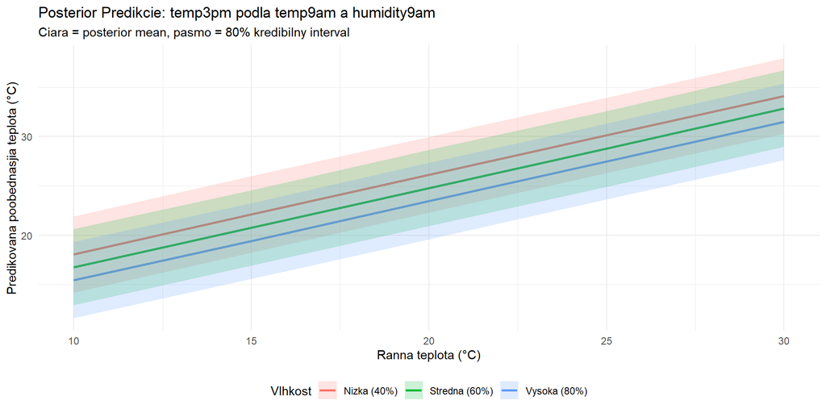

```r
# Predikcie pre rozne scenare
new_data <- expand.grid(
  temp9am = seq(10, 30, by = 5),
  humidity9am = c(40, 60, 80)
)

predictions <- posterior_predict(model_2, newdata = new_data)

pred_summary <- new_data %>%
  mutate(
    pred_mean = colMeans(predictions),
    pred_lower = apply(predictions, 2, quantile, 0.1),
    pred_upper = apply(predictions, 2, quantile, 0.9),
    humidity_level = factor(humidity9am, labels = c("Nizka (40%)", "Stredna (60%)", "Vysoka (80%)"))
  )

ggplot(pred_summary, aes(x = temp9am, y = pred_mean, color = humidity_level)) +
  geom_line(linewidth = 1) +
  geom_ribbon(aes(ymin = pred_lower, ymax = pred_upper, fill = humidity_level),
              alpha = 0.2, color = NA) +
  labs(title = "Posterior Predikcie: temp3pm podla temp9am a humidity9am",
       subtitle = "Ciara = posterior mean, pasmo = 80% kredibilny interval",
       x = "Ranna teplota (°C)",
       y = "Predikovana poobednasjia teplota (°C)",
       color = "Vlhkost", fill = "Vlhkost") +
  theme_minimal() +
  theme(legend.position = "bottom")
```

# Zaverecne Poznamky

## Proces modelovania

1. **EDA**: Preskumanie dat a identifikacia potencialnych prediktorov
2. **Prior specifikacia**: Weakly informative priory na zaklade predporozumenia
3. **Postupne budovanie**: Od jednoduchych k zlozitejsim modelom
4. **MCMC diagnostika**: Overenie konvergencie pre kazdy model
5. **Porovnanie modelov**: Cross-validacia a ELPD
6. **Vyber modelu**: Rovnovaha medzi presnostou a jednoduchostou